# Exporatory Analysis of Population Healthcare Data

10/26/2021

## Introduction

This study aims to understand population health data in Accountable Care Organization (ACO), we perform descriptive analysis of the inpatient stay, member demographics and identify key drivers of healthcare cost and readmission rate. We conduct studies as follows:

- Read the data, perform exploratory data analysis (data type, summary statistics)
- Calculate the inpatient stays, examine the ACO members, e.g. count member by features
- Explore cost vs. member features
- Reveal cost relationship with member features
- Calculate readmission rate, identify features with high readmission rate

## Key findings

- The average inpatient stay is about 6.7 days, with the maximum stay as 238 days and minimum 0 day
- The length of stay is highly skewed.
- The average cost per patient is about $6000 with high variation, members with certain features incur high costs, such as discharge facility (type), Age etc
- The readmission rate varies across ethic groups, for example, the female readmission rate is much higher than male.

## Exploratory data analytics

We read the data

```r
options(width = 60)
library(readr)
IPClaims <- read.csv("IPClaims.csv", header = TRUE)
IPClaims <- IPClaims %>%  # change payment to numerical
  mutate(Paid.Amount = parse_number(Paid.Amount))
dim(IPClaims);names(IPClaims)
```

```
## [1] 9993    7
```

```
## [1] "Member.ID"                 "Discharge.facility"
## [3] "Discharge.facility.type"   "Admission.Diagnosis.Group"
## [5] "Admission.Date"            "Discharge.Date"
## [7] "Paid.Amount"
```

```r
options(width = 60)
library(readr)
ACORoster <- read.csv("ACORoster.csv", header = TRUE)
dim(ACORoster);names(ACORoster)
```

```
## [1] 3515    6
```

```
## [1] "Member.ID"         "Primary.Care.Site"
## [3] "Sex"               "Race"
## [5] "Disabled"          "Age"
```

## Data types

```r
sapply(IPClaims, typeof)
```

```
##                 Member.ID        Discharge.facility
##                 "integer"               "character"
##   Discharge.facility.type Admission.Diagnosis.Group
##               "character"               "character"
##            Admission.Date            Discharge.Date
##               "character"               "character"
##               Paid.Amount
##                  "double"
```

```r
sapply(ACORoster, typeof)
```

```
##         Member.ID Primary.Care.Site               Sex
##         "integer"       "character"       "character"
##              Race          Disabled               Age
##       "character"       "character"         "integer"
```

## Cost

```r
summary(IPClaims$Paid.Amount)
```

```
##    Min. 1st Qu.  Median    Mean 3rd Qu.    Max.
##    1000    3498    5996    5996    8494   10992
```

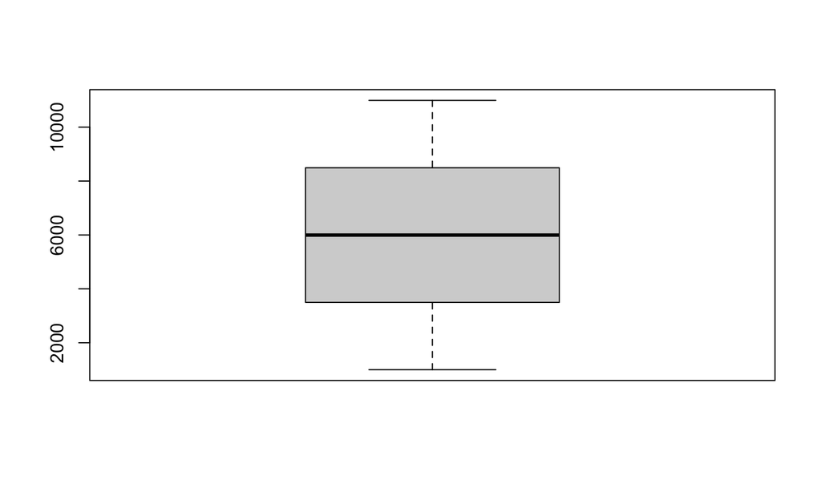

```r
boxplot(IPClaims$Paid.Amount)
```

## Inpatient stays

Inpatient stay is the interval between admission date and discharge date

```r
IPClaims_inpatient <- IPClaims %>%
  group_by(Member.ID) %>%
  mutate(Admission.Date=as.Date(Admission.Date, "%m/%d/%y"),
         Discharge.Date=as.Date(Discharge.Date, "%m/%d/%y")) %>%
  mutate(inpatientstay = as.numeric(difftime(Discharge.Date, Admission.Date, units = "days"))) %>%
  filter(inpatientstay >= 0)
summary(IPClaims_inpatient$inpatientstay)
```

```
##    Min. 1st Qu.  Median    Mean 3rd Qu.    Max.
##   0.000   2.000   4.000   6.734   7.000 238.000
```

We can see the inpatient stay is highly skewed

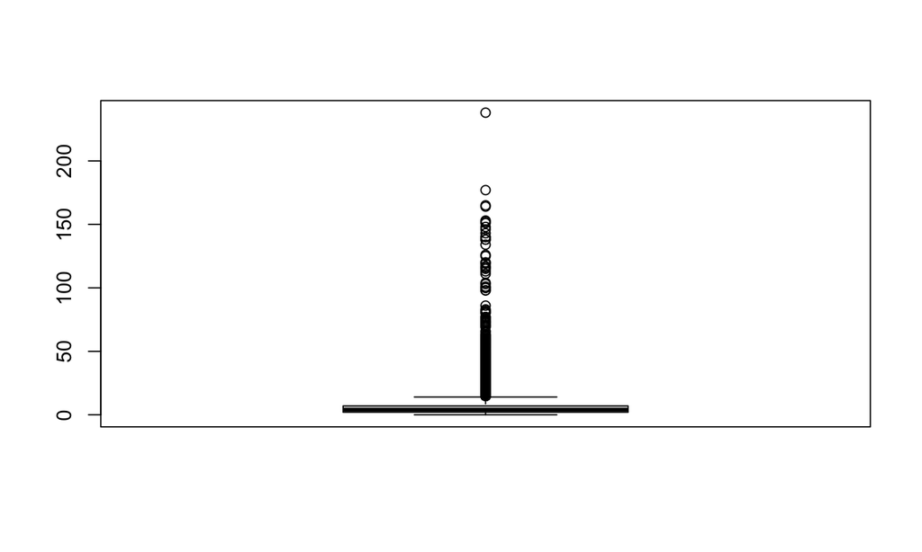

```r
boxplot(IPClaims_inpatient$inpatientstay)
```

## Member count vs. features

We have total 6198 distinct member IDs. The Members who have the top number of visits are as follows:

| Member.ID | n |
| --- | --- |
| 752729 | 21 |
| 7898203 | 18 |
| 465235 | 16 |
| 1424722 | 15 |
| 544068 | 14 |
| 5269595 | 14 |

We have 140 discharge facilities. For example:

| Discharge.facility | n |
| --- | --- |
| BOSTON MEDICAL CENTER CORPORATION | 1280 |
| SOUTHCOAST HOSPITALS GROUP, INC | 1248 |
| HIGH POINT TREATMENT CENTER INC. | 499 |
| BAYSTATE MEDICAL CENTER INC | 398 |
| THE MERCY HOSPITAL INC | 386 |
| BROCKTON HOSPITAL, INC. | 348 |

There are 3 Discharge facility types.

| Discharge.facility.type | n |
| --- | --- |
| Medical | 6982 |
| BH | 2911 |
| Post acute | 100 |

255 Admission Diagnosis Groups.

| Admission.Diagnosis.Group | n |
| --- | --- |
| MAJOR DEPRESSIVE DISORDERS & OTHER/UNSPECIFIED PSYCHOSES | 691 |
| BIPOLAR DISORDERS | 638 |
| OPIOID ABUSE & DEPENDENCE | 626 |
| ALCOHOL ABUSE & DEPENDENCE | 623 |
| SCHIZOPHRENIA | 383 |
| NULL | 341 |

## Combining Claim Data with ACO Roster Data

```r
Claim_Roster<- IPClaims %>% left_join(ACORoster, by = "Member.ID")
dim(Claim_Roster); names(Claim_Roster)
```

```
## [1] 9993   12
```

```
##  [1] "Member.ID"                 "Discharge.facility"
##  [3] "Discharge.facility.type"   "Admission.Diagnosis.Group"
##  [5] "Admission.Date"            "Discharge.Date"
##  [7] "Paid.Amount"               "Primary.Care.Site"
##  [9] "Sex"                       "Race"
## [11] "Disabled"                  "Age"
```

46 Primary Care Sites

|  | Primary.Care.Site | n |
| --- | --- | --- |
| 2 | Evans Medical Foundation, Inc | 1022 |
| 3 | Greater New Bedford Community Health Center | 847 |
| 4 | McInnis Health Group | 818 |
| 5 | Signature Medical Group | 703 |
| 6 | Manet Community Health Center | 675 |
| 7 | Family Health Care at SSTAR | 422 |

Member count by Sex

|  | Sex | n |
| --- | --- | --- |
| 1 | F - Female | 7062 |
| 3 | M - Male | 248 |

Member count by Race

|  | Race | n |
| --- | --- | --- |
| 1 | UNKNOW - RACE UNKNOWN | 3062 |
| 3 | BLACK - BLACK-NOT OF HISPANIC ORIGIN | 1995 |
| 4 | WHITE - CAUCASIAN | 1541 |
| 5 | HISPAN - HISPANIC | 443 |
| 6 | INTER - INTERRACIAL | 146 |
| 7 | ASIAN - ASIAN OR PACIFIC ISLANDER | 96 |
| 8 | INDIAN - AMERICAN INDIAN OR ALASKAN AMERICAN | 27 |

Member count by Disability

|  | Disabled | n |
| --- | --- | --- |
| 1 | N | 6584 |
| 3 | Y | 726 |

Totally 33 different Age categories, we list a few

|  | Age | n |
| --- | --- | --- |
| 2 | 27 | 453 |
| 3 | 20 | 450 |
| 4 | 26 | 447 |
| 5 | 24 | 401 |
| 6 | 22 | 387 |
| 7 | 31 | 382 |

## Cost versus member features

Box plot of all costs

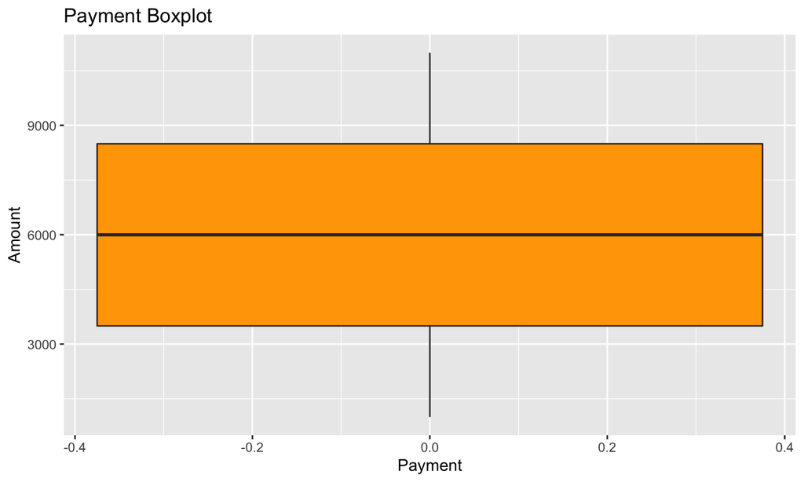

Box plot of cost vs. Discharge facility

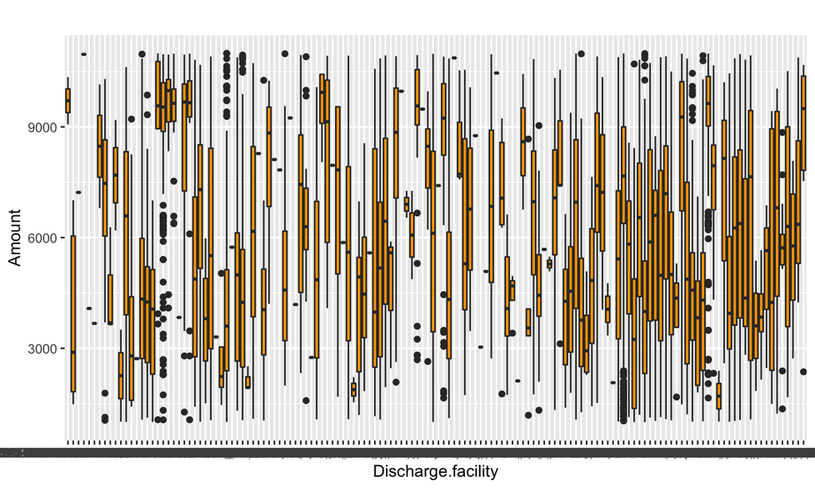

The mean cost rank by Discharge facility. Examples:

| Discharge.facility | count | mean | cost |
| --- | --- | --- | --- |
| 193 PLEASANT STREET OPERATOR LLC | 1 | 10966.00 | 10966 |
| KENDALL HEALTHCARE GROUP, LTD. | 1 | 10868.00 | 10868 |
| MARY HITCHCOCK MEMORIAL HOSPITAL | 2 | 10459.50 | 20919 |
| GREENWICH HOSPITAL | 1 | 9965.00 | 9965 |
| 1200 SUFFIELD STREET OPERATOR LLC | 2 | 9707.50 | 19415 |
| CONCORD HOSPITAL, INC. | 4 | 9584.25 | 38337 |

The total cost rank by Discharge facility

| Discharge.facility | count | mean | cost |
| --- | --- | --- | --- |
| SOUTHCOAST HOSPITALS GROUP, INC | 1248 | 7405.270 | 9241777 |
| BOSTON MEDICAL CENTER CORPORATION | 1280 | 3856.318 | 4936087 |
| BAYSTATE MEDICAL CENTER INC | 398 | 9085.497 | 3616028 |
| THE MERCY HOSPITAL INC | 386 | 9273.365 | 3579519 |
| HIGH POINT TREATMENT CENTER INC. | 499 | 5898.383 | 2943293 |
| BROCKTON HOSPITAL, INC. | 348 | 5954.891 | 2072302 |

Boxplot: Cost vs. Discharge facility type

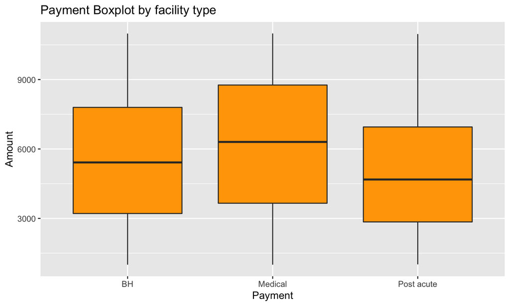

The mean cost rank by Discharge facility type

| Discharge.facility.type | count | mean | cost |
| --- | --- | --- | --- |
| Medical | 6982 | 6186.933 | 43197169 |
| BH | 2911 | 5571.967 | 16219996 |
| Post acute | 100 | 5008.630 | 500863 |

The total cost rank by Discharge facility type

| Discharge.facility.type | count | mean | cost |
| --- | --- | --- | --- |
| Medical | 6982 | 6186.933 | 43197169 |
| BH | 2911 | 5571.967 | 16219996 |
| Post acute | 100 | 5008.630 | 500863 |

The mean cost rank by Admission Diagnosis Group

| Admission.Diagnosis.Group | count | mean | cost |
| --- | --- | --- | --- |
| FRACTURE OF PELVIS OR DISLOCATION OF HIP | 2 | 10185.500 | 20371 |
| VAGINAL DELIVERY W/ STERILIZATION &/OR D&C | 1 | 9953.000 | 9953 |
| OTHER PROCEDURES FOR ENDOCRINE, NUTRITITIONAL & METABOLIC DISORDERS | 1 | 9905.000 | 9905 |
| FEMALE REPRODUCTIVE SYSTEM RECONSTRUCTIVE PROCEDURES | 1 | 9798.000 | 9798 |
| ORBITAL PROCEDURES | 1 | 9230.000 | 9230 |
| PERM CARDIAC PACEMAKER IMPLANT W/O AMI, HEART FAILURE OR SHOCK | 3 | 8825.667 | 26477 |

The total cost rank by Admission Diagnosis Group

| Admission.Diagnosis.Group | count | mean | cost |
| --- | --- | --- | --- |
| MAJOR DEPRESSIVE DISORDERS & OTHER/UNSPECIFIED PSYCHOSES | 691 | 5965.375 | 4122074 |
| BIPOLAR DISORDERS | 638 | 6057.627 | 3864766 |
| ALCOHOL ABUSE & DEPENDENCE | 623 | 5932.838 | 3696158 |
| OPIOID ABUSE & DEPENDENCE | 626 | 5524.411 | 3458281 |
| SCHIZOPHRENIA | 383 | 5548.851 | 2125210 |
| NULL | 341 | 5844.757 | 1993062 |

The mean cost rank by Primary Care Site

| Primary.Care.Site | count | mean | cost |
| --- | --- | --- | --- |
| Primary Cardiology of Attleboro | 1 | 8259.000 | 8259 |
| Leav, Brett Ashley | 4 | 7902.500 | 31610 |
| Fall River Nephrology,PC | 6 | 7635.500 | 45813 |
| Southcoast Cardiology LLC | 10 | 7519.200 | 75192 |
| Geriatric Internal Medicine Specialists, LLC | 30 | 7024.333 | 210730 |
| Riverbend Med. Grp, Inc/Trinity Health of New England | 3 | 6479.000 | 19437 |

The total cost rank by Primary Care Site

| Primary.Care.Site | count | mean | cost |
| --- | --- | --- | --- |
| Greater New Bedford Community Health Center | 847 | 6269.257 | 5310061 |
| Evans Medical Foundation, Inc | 1022 | 3627.840 | 3707652 |
| Manet Community Health Center | 675 | 5069.136 | 3421667 |
| McInnis Health Group | 818 | 3955.542 | 3235633 |
| Signature Medical Group | 703 | 4462.461 | 3137110 |
| Southcoast Physicians Group, Inc. | 366 | 6018.022 | 2202596 |

Cost by Sex

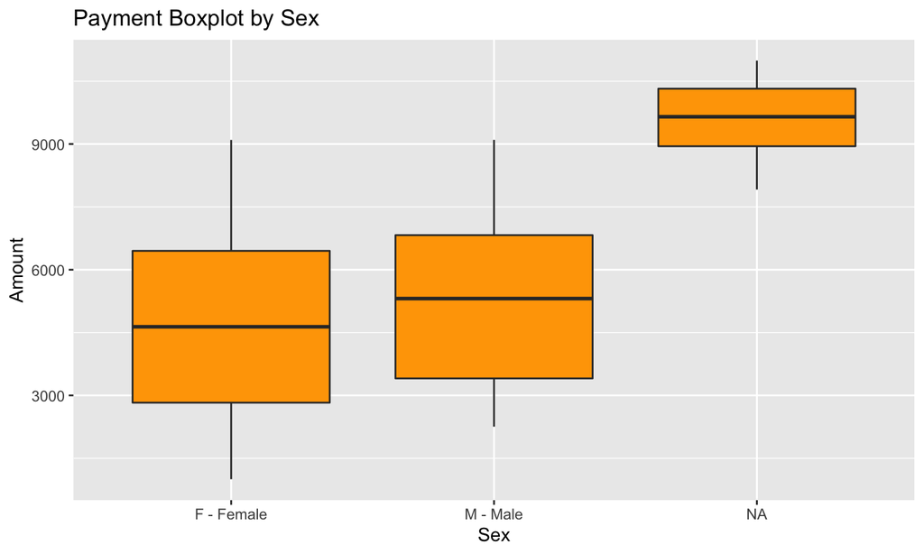

The total cost rank by Sex

| Sex | count | mean | cost |
| --- | --- | --- | --- |
| F - Female | 7062 | 4648.537 | 32827970 |
| M - Male | 248 | 5234.000 | 1298032 |

Cost by Race

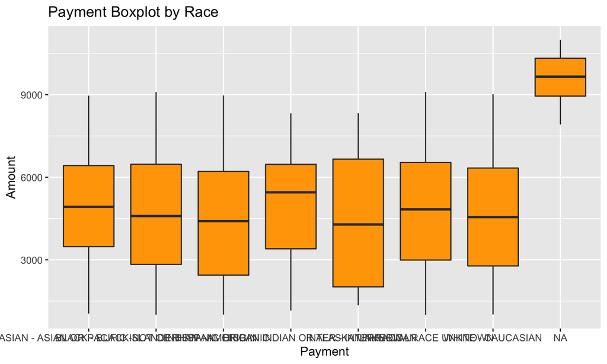

The total cost rank by Race (all races)

| Race | count | mean | cost |
| --- | --- | --- | --- |
| UNKNOW - RACE UNKNOWN | 3062 | 4813.085 | 14737665 |
| BLACK - BLACK-NOT OF HISPANIC ORIGIN | 1995 | 4566.357 | 9109882 |
| WHITE - CAUCASIAN | 1541 | 4568.487 | 7040039 |
| HISPAN - HISPANIC | 443 | 4506.018 | 1996166 |
| INTER - INTERRACIAL | 146 | 4318.945 | 630566 |
| ASIAN - ASIAN OR PACIFIC ISLANDER | 96 | 5008.094 | 480777 |
| INDIAN - AMERICAN INDIAN OR ALASKAN AMERICAN | 27 | 4848.407 | 130907 |

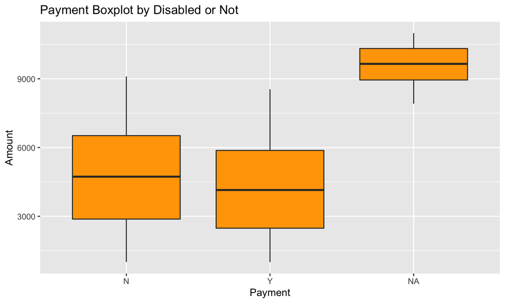

The total cost rank by disabled or not

| Disabled | count | mean | cost |
| --- | --- | --- | --- |
| N | 6584 | 4721.106 | 31083759 |
| Y | 726 | 4190.417 | 3042243 |

The mean cost rank by Age

| Age | count | mean | cost |
| --- | --- | --- | --- |
| 1 | 66 | 5380.879 | 355138 |
| 0 | 182 | 5180.736 | 942894 |
| 44 | 31 | 5061.000 | 156891 |
| 16 | 29 | 4971.000 | 144159 |
| 43 | 12 | 4917.833 | 59014 |
| 46 | 9 | 4845.444 | 43609 |

The total cost rank by Age

| Age | count | mean | cost |
| --- | --- | --- | --- |
| 20 | 450 | 4756.493 | 2140422 |
| 27 | 453 | 4644.166 | 2103807 |
| 26 | 447 | 4468.013 | 1997202 |
| 24 | 401 | 4723.411 | 1894088 |
| 31 | 382 | 4744.751 | 1812495 |
| 22 | 387 | 4559.207 | 1764413 |

## Readmission rate

Identify members had readmission

```r
IPClaims_v1 <- IPClaims %>%
  group_by(Member.ID) %>%
  mutate(Admission.Date=as.Date(Admission.Date, "%m/%d/%y"),
         Discharge.Date=as.Date(Discharge.Date, "%m/%d/%y")) %>%
  mutate(count_member= n(), Discharge.Date_lead = lead(Discharge.Date)) %>%
  filter(!is.na(Discharge.Date_lead)) %>%
  mutate(Discharge.Date_min = min(Discharge.Date_lead)) %>%
  mutate(readmission = ifelse(Admission.Date >= Discharge.Date_min+30,"Y","N"))
```

Readmission rate at the member level, we find the members with top readmission rate

```r
library(formattable)
re_ad_ind <- IPClaims %>%
  group_by(Member.ID) %>%
  mutate(Admission.Date=as.Date(Admission.Date, "%m/%d/%y"),
         Discharge.Date=as.Date(Discharge.Date, "%m/%d/%y")) %>%
  mutate(count_member= n(), Discharge.Date_lead = lead(Discharge.Date)) %>%
  filter(!is.na(Discharge.Date_lead)) %>%
  mutate(Discharge.Date_min = min(Discharge.Date_lead)) %>%
  mutate(readmission = ifelse(Admission.Date >= Discharge.Date_min+30,"Y","N")) %>%
  summarize(count =count_member, mean=mean(Paid.Amount,na.rm=TRUE),
            re_ad_count=sum(readmission == "Y"),
            cost=sum(Paid.Amount,na.rm=TRUE)) %>%
  mutate(re_ad_rate = percent(re_ad_count/count))
re_ad_ind_v1 <- re_ad_ind %>% arrange(desc(re_ad_rate))

kable(head(re_ad_ind_v1))
```

| Member.ID | count | mean | re_ad_count | cost | re_ad_rate |
| --- | --- | --- | --- | --- | --- |
| 2590929 | 13 | 4884.333 | 10 | 58612 | 76.92% |
| 2590929 | 13 | 4884.333 | 10 | 58612 | 76.92% |
| 2590929 | 13 | 4884.333 | 10 | 58612 | 76.92% |
| 2590929 | 13 | 4884.333 | 10 | 58612 | 76.92% |
| 2590929 | 13 | 4884.333 | 10 | 58612 | 76.92% |
| 2590929 | 13 | 4884.333 | 10 | 58612 | 76.92% |

Individual total cost vs. Readmission rate

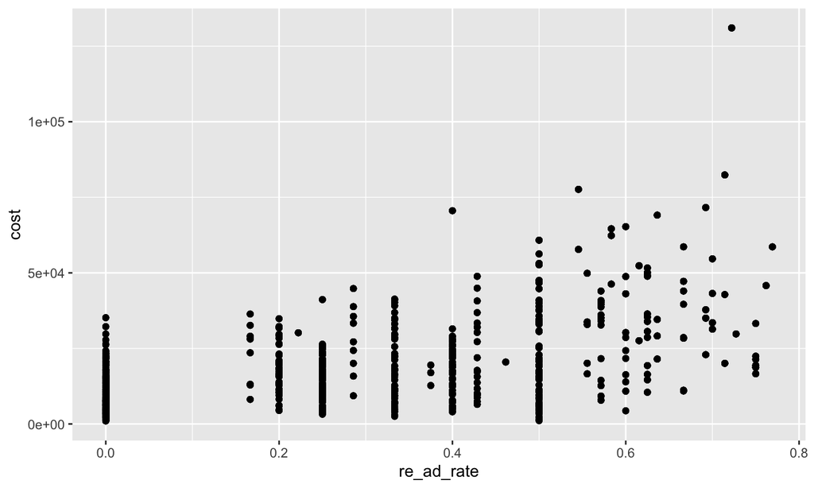

```r
qplot(re_ad_rate,cost, data=re_ad_ind)
```

Individual mean cost vs. Readmission rate

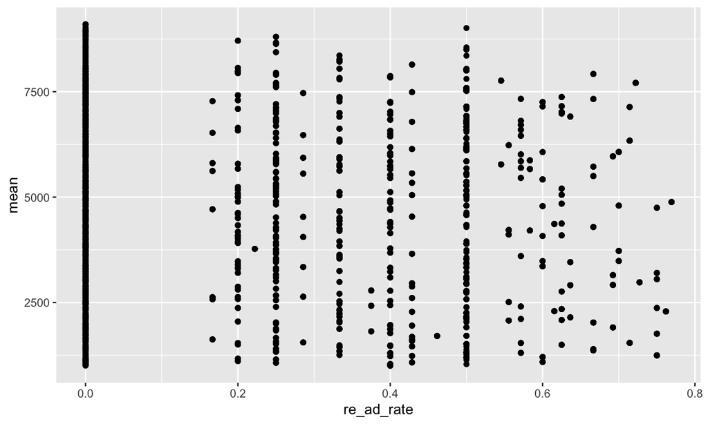

```r
qplot(re_ad_rate,mean, data=re_ad_ind)
```

Readmission rate rank by Discharge facility

```r
re_ad_Discharge.facility  <- IPClaims_v1 %>%
  group_by(Discharge.facility) %>%
  summarize(mean=mean(Paid.Amount,na.rm=TRUE), re_ad_count=sum(readmission == "Y"),
            cost=sum(Paid.Amount,na.rm=TRUE)) %>%
  inner_join(IPClaims[,c("Member.ID", "Discharge.facility")],
             by = "Discharge.facility") %>%
  mutate(count_member= n(),re_ad_rate = percent(re_ad_count/count_member)) %>%
  select(-Member.ID) %>%
  arrange(desc(re_ad_rate)) %>% distinct()
```

```r
kable(head(re_ad_Discharge.facility))
```

| Discharge.facility | mean | re_ad_count | cost | count_member | re_ad_rate |
| --- | --- | --- | --- | --- | --- |
| BOSTON MEDICAL CENTER CORPORATION | 3699.639 | 160 | 2020003 | 9952 | 1.61% |
| SOUTHCOAST HOSPITALS GROUP, INC | 6416.585 | 78 | 2303554 | 9952 | 0.78% |
| HIGH POINT TREATMENT CENTER INC. | 4734.259 | 72 | 1245110 | 9952 | 0.72% |
| STANLEY STREET TREATMENT AND RESOURCES, INC. | 5545.417 | 48 | 665450 | 9952 | 0.48% |
| THE GENERAL HOSPITAL CORPORATION | 4093.304 | 47 | 470730 | 9952 | 0.47% |
| BAY COVE HUMAN SERVICES, INC | 3960.602 | 39 | 348533 | 9952 | 0.39% |

Rank by Discharge facility type

| Discharge.facility.type | mean | re_ad_count | cost | count_member | re_ad_rate |
| --- | --- | --- | --- | --- | --- |
| Medical | 4630.347 | 634 | 10409020 | 9993 | 6.34% |
| BH | 4526.159 | 496 | 6789239 | 9993 | 4.96% |
| Post acute | 4269.319 | 7 | 200658 | 9993 | 0.07% |

Rank by Admission Diagnosis Group

| Admission.Diagnosis.Group | mean | re_ad_count | cost | count_member | re_ad_rate |
| --- | --- | --- | --- | --- | --- |
| OPIOID ABUSE & DEPENDENCE | 4278.179 | 125 | 1484528 | 9846 | 1.27% |
| ALCOHOL ABUSE & DEPENDENCE | 4673.678 | 113 | 1392756 | 9846 | 1.15% |
| BIPOLAR DISORDERS | 4683.673 | 100 | 1288010 | 9846 | 1.02% |
| MAJOR DEPRESSIVE DISORDERS & OTHER/UNSPECIFIED PSYCHOSES | 4649.363 | 84 | 1422705 | 9846 | 0.85% |
| NULL | 4627.769 | 74 | 860765 | 9846 | 0.75% |
| DRUG & ALCOHOL ABUSE OR DEPENDENCE, LEFT AGAINST MEDICAL ADVICE | 4510.107 | 54 | 590824 | 9846 | 0.55% |

Rank by Primary Care Site

| Primary.Care.Site | mean | re_ad_count | cost | count_member | re_ad_rate |
| --- | --- | --- | --- | --- | --- |
| Evans Medical Foundation, Inc | 3545.558 | 167 | 1900419 | 7306 | 2.29% |
| McInnis Health Group | 3964.430 | 160 | 1807780 | 7306 | 2.19% |
| Greater New Bedford Community Health Center | 6256.274 | 104 | 2621379 | 7306 | 1.42% |
| Signature Medical Group | 4264.427 | 98 | 1496814 | 7306 | 1.34% |
| Manet Community Health Center | 5004.127 | 96 | 1731428 | 7306 | 1.31% |
| Family Health Care at SSTAR | 4801.974 | 82 | 1104454 | 7306 | 1.12% |

By Sex

| Sex | mean | re_ad_count | cost | count_member | re_ad_rate |
| --- | --- | --- | --- | --- | --- |
| F - Female | 4571.869 | 1109 | 16833621 | 7310 | 15.17% |
| M - Male | 5002.619 | 28 | 565296 | 7310 | 0.38% |

By Race

| Race | mean | re_ad_count | cost | count_member | re_ad_rate |
| --- | --- | --- | --- | --- | --- |
| UNKNOW - RACE UNKNOWN | 4720.558 | 458 | 7373512 | 7310 | 6.27% |
| BLACK - BLACK-NOT OF HISPANIC ORIGIN | 4492.280 | 289 | 4627048 | 7310 | 3.95% |
| WHITE - CAUCASIAN | 4527.330 | 253 | 3716938 | 7310 | 3.46% |
| HISPAN - HISPANIC | 4345.609 | 90 | 1055983 | 7310 | 1.23% |
| INTER - INTERRACIAL | 4080.372 | 36 | 350912 | 7310 | 0.49% |
| ASIAN - ASIAN OR PACIFIC ISLANDER | 5107.707 | 8 | 209416 | 7310 | 0.11% |
| INDIAN - AMERICAN INDIAN OR ALASKAN AMERICAN | 5425.667 | 3 | 65108 | 7310 | 0.04% |

By Disabled or not

| Disabled | mean | re_ad_count | cost | count_member | re_ad_rate |
| --- | --- | --- | --- | --- | --- |
| N | 4651.392 | 1028 | 15879851 | 7310 | 14.06% |
| Y | 3987.050 | 109 | 1519066 | 7310 | 1.49% |

By Age

| Age | mean | re_ad_count | cost | count_member | re_ad_rate |
| --- | --- | --- | --- | --- | --- |
| 32 | 4377.154 | 82 | 936711 | 7310 | 1.12% |
| 20 | 4676.667 | 80 | 1122400 | 7310 | 1.09% |
| 26 | 4303.335 | 75 | 1041407 | 7310 | 1.03% |
| 22 | 4368.585 | 71 | 926140 | 7310 | 0.97% |
| 23 | 4873.371 | 63 | 828473 | 7310 | 0.86% |
| 31 | 4789.444 | 62 | 991415 | 7310 | 0.85% |